# ESS 330 - Lab 8: Machine Learning

Author

Ava Zelenz

Published

April 16, 2025

## I. Set Up Lab

### 1. Library Code

```r
library(tidyverse)
library(tidymodels)
library(powerjoin)
library(glue)
library(vip)
library(baguette)
library(patchwork)
```

### 2. Data Import

```r
root  <- 'https://gdex.ucar.edu/dataset/camels/file'

download.file('https://gdex.ucar.edu/dataset/camels/file/camels_attributes_v2.0.pdf',
              'data/camels_attributes_v2.0.pdf')

types <- c("clim", "geol", "soil", "topo", "vege", "hydro")

remote_files  <- glue('{root}/camels_{types}.txt')

local_files   <- glue('data/camels_{types}.txt')

walk2(remote_files, local_files, download.file, quiet = TRUE)

camels <- map(local_files, read_delim, show_col_types = FALSE)

camels <- power_full_join(camels ,by = 'gauge_id')
```

### 3. Data Cleaning and Splitting into Test/Train Datasets

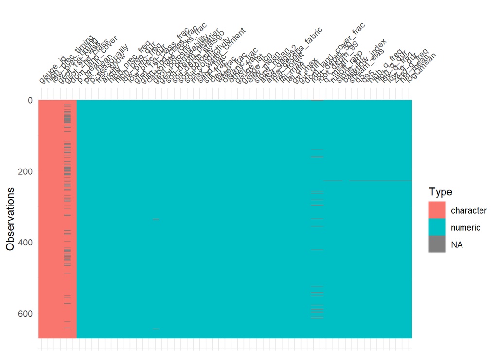

```r
camels <- camels |>
  mutate(logQmean = log(q_mean))

visdat::vis_dat(camels)
```

```r
camels <- camels |>
  drop_na()

set.seed(123)
camels_split <- initial_split(camels, prop = .8, strata = q_mean)

camels_training <- training(camels_split)
camels_testing <- testing(camels_split)
```

## II. Resampling and Model Testing

### 1. Recipe and Data Baking

```r
# Recipe
rec <- recipe(logQmean ~ soil_porosity + soil_depth_pelletier + gauge_lat + gauge_lon, data = camels_training) |>
  update_role(gauge_lat, gauge_lon, new_role = "id") |>
  step_log(all_predictors(), offset = 1e-6) |>
  step_naomit(all_predictors(), all_outcomes())

# Baking Data
baked_data <- prep(rec, camels_training) |>
  bake(new_data = NULL)
```

### 2. Building Resamples and 3 Models

```r
# Cross Validation
fold_camels <- vfold_cv(camels_training, v = 10)

# Linear Model
lm_model <- linear_reg() |>
  set_engine("lm") |>
  set_mode("regression")

# Random Forest
rf_model <- rand_forest() |>
  set_engine("ranger", importance = "impurity") |>
  set_mode("regression")

# Decision Tree
dt_model <- decision_tree() |>
  set_engine("rpart") |>
  set_mode("regression")
```

### 3. Workflow Set and Testing Models

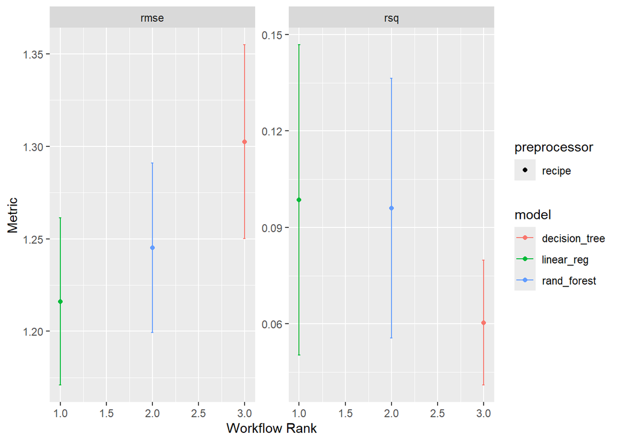

```r
# Workflow Model List
model_list <- list(
  linear = lm_model,
  random_forest = rf_model,
  decision_tree = dt_model
)

# Workflow
camels_workflows <- workflow_set(
  preproc = list(basic_recipe = rec),
  models = model_list
)

# Fit to resamples
results <- camels_workflows |>
  workflow_map("fit_resamples", resamples = fold_camels)
# Visualize
autoplot(results)
```

### 4. Model Selection

#### The model that will best fit is the linear_reg model. The model’s range of rmse is lowest and has a decent rsq, meaning that it is making the most accurate predictions and performs the best out of the three.

#### **Model Selected**: Linear Regression

> **Engine**: “lm”

> **Mode**: “Regression”

> **Reason for choice**: high accuracy of predictions and simple results based on variable connection.

## III. Model Tuning

### 1. Building a Model for Chosen Specification

```r
# Linear Model with Hyperparameters

tuned_lm_model <- linear_reg(
  penalty = tune(),
  mixture = tune()
) |>
  set_engine("glmnet") |>
  set_mode("regression")

lm_workflow <- workflow() |>
  add_model(tuned_lm_model) |>
  add_recipe(rec)

# Checking Tunable Values and Ranges
dials <- extract_parameter_set_dials(lm_workflow)

dials$object
```

```
Amount of Regularization (quantitative)
```

```
Transformer: log-10 [1e-100, Inf]
```

```
Range (transformed scale): [-10, 0]
```

```
Proportion of Lasso Penalty (quantitative)
```

```
Range: [0.05, 1]
```

### 2. Define the Search Space and Tuning Model

```r
library(glmnet)
my.grid <- grid_space_filling(
  dials,
  size = 25
)

my.grid
```

```
# A tibble: 25 × 2
    penalty mixture
      <dbl>   <dbl>
 1 1   e-10  0.604
 2 2.61e-10  0.327
 3 6.81e-10  0.842
 4 1.78e- 9  0.129
 5 4.64e- 9  0.485
 6 1.21e- 8  0.683
 7 3.16e- 8  0.921
 8 8.25e- 8  0.288
 9 2.15e- 7  0.0896
10 5.62e- 7  0.525
# ℹ 15 more rows
```

```r
model_params <-  tune_grid(
    lm_workflow,
    resamples = fold_camels,
    grid = my.grid,
    metrics = metric_set(rmse, rsq, mae),
    control = control_grid(save_pred = TRUE)
  )
```

[output not shown]

[output not shown]

[output not shown]

[output not shown]

[output not shown]

[output not shown]

[output not shown]

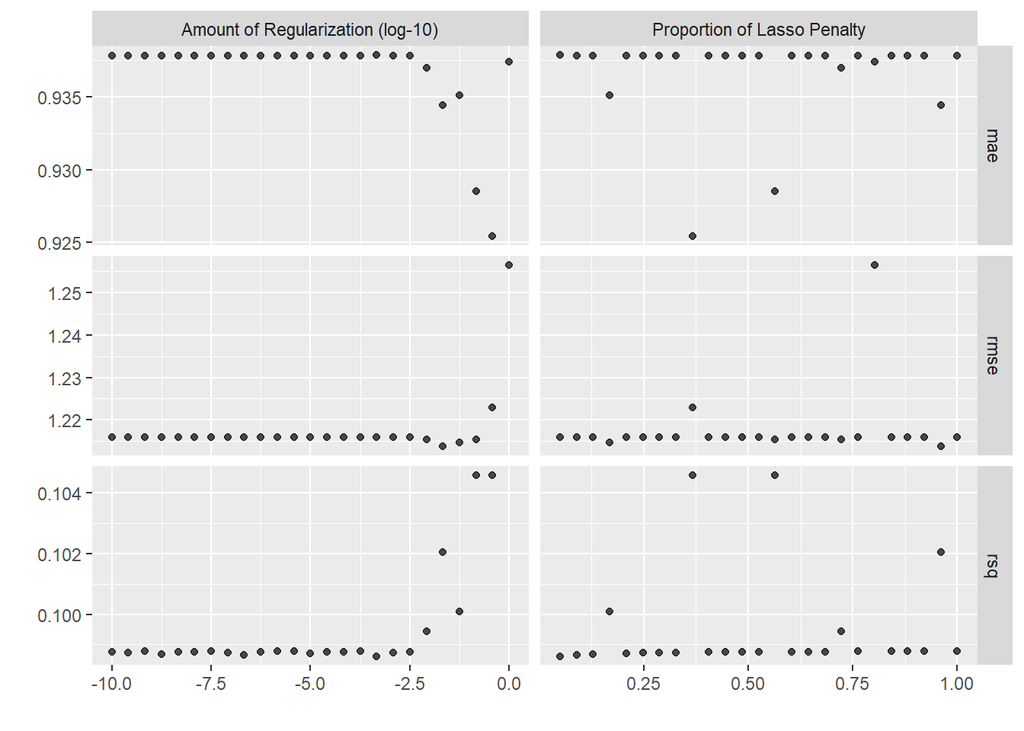

```r
autoplot(model_params)
```

### 3. Check Skill of Tuned Model

```r
collect_metrics(model_params)
```

```
# A tibble: 75 × 8
         penalty mixture .metric .estimator   mean     n std_err .config
           <dbl>   <dbl> <chr>   <chr>       <dbl> <int>   <dbl> <chr>
 1 0.000464       0.05   mae     standard   0.938     10  0.0189 Preprocessor1_…
 2 0.000464       0.05   rmse    standard   1.22      10  0.0276 Preprocessor1_…
 3 0.000464       0.05   rsq     standard   0.0986    10  0.0293 Preprocessor1_…
 4 0.000000215    0.0896 mae     standard   0.938     10  0.0189 Preprocessor1_…
 5 0.000000215    0.0896 rmse    standard   1.22      10  0.0276 Preprocessor1_…
 6 0.000000215    0.0896 rsq     standard   0.0986    10  0.0293 Preprocessor1_…
 7 0.00000000178  0.129  mae     standard   0.938     10  0.0189 Preprocessor1_…
 8 0.00000000178  0.129  rmse    standard   1.22      10  0.0276 Preprocessor1_…
 9 0.00000000178  0.129  rsq     standard   0.0987    10  0.0294 Preprocessor1_…
10 0.0562         0.169  mae     standard   0.935     10  0.0191 Preprocessor1_…
# ℹ 65 more rows
```

```r
show_best(model_params, metric = "mae", n = 1)
```

```
# A tibble: 1 × 8
  penalty mixture .metric .estimator  mean     n std_err .config
    <dbl>   <dbl> <chr>   <chr>      <dbl> <int>   <dbl> <chr>
1   0.383   0.367 mae     standard   0.925    10  0.0223 Preprocessor1_Model09
```

```r
hp_best <- select_best(model_params, metric = "mae")
```

### 4. Finalizing the Model

```r
finalized_workflow <- finalize_workflow(
  lm_workflow,
  hp_best
)

final_fit <- fit(finalized_workflow, data = camels_training)

final_res <- last_fit(finalized_workflow, split = camels_split)

collect_metrics(final_res)
```

```
# A tibble: 2 × 4
  .metric .estimator .estimate .config
  <chr>   <chr>          <dbl> <chr>
1 rmse    standard      1.20   Preprocessor1_Model1
2 rsq     standard      0.0587 Preprocessor1_Model1
```

```r
collect_predictions(final_res)
```

```
# A tibble: 104 × 5
     .pred id                .row logQmean .config
     <dbl> <chr>            <int>    <dbl> <chr>
 1 -0.432  train/test split     1  0.776   Preprocessor1_Model1
 2 -0.122  train/test split     4  0.878   Preprocessor1_Model1
 3 -0.249  train/test split     7  0.601   Preprocessor1_Model1
 4 -0.357  train/test split    16  0.608   Preprocessor1_Model1
 5 -0.261  train/test split    29  0.586   Preprocessor1_Model1
 6 -0.251  train/test split    31  0.642   Preprocessor1_Model1
 7 -0.0956 train/test split    36  0.266   Preprocessor1_Model1
 8 -0.0779 train/test split    44 -0.00956 Preprocessor1_Model1
 9 -0.0942 train/test split    45 -0.00340 Preprocessor1_Model1
10 -0.0974 train/test split    46  0.132   Preprocessor1_Model1
# ℹ 94 more rows
```

> **Metrics and Model Analyses**

#### Although the RMSE is 1.2, indicating that the predictions are reasonably close to the observed values, the very low R² suggests the model fails to capture much of the underlying variability. This implies that the selected predictors—soil porosity and depth to bedrock—are not particularly effective for modeling q_mean.

### 5. Creating a Scatterplot

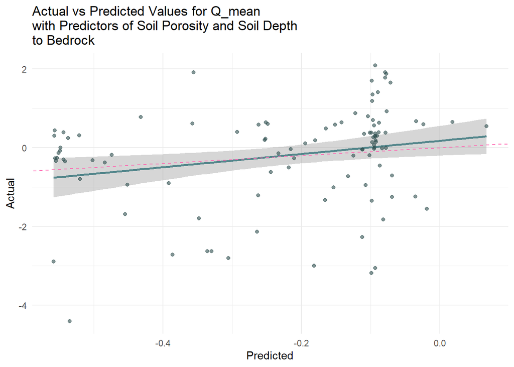

```r
final_res |>
  collect_predictions() |>
  ggplot(aes(x = .pred, y = logQmean)) +
  geom_smooth(method = "lm",  color = "#53868B") +
  geom_point(alpha = 0.6, color = "#2F4F4F") +
  geom_abline(slope = 1, intercept = 0, color = "#FF6EB4", linetype = "dashed") +
  scale_color_viridis_c(option = "plasma") +
  labs(
    x = "Predicted",
    y = "Actual",
    title = "Actual vs Predicted Values for Q_mean\nwith Predictors of Soil Porosity and Soil Depth\nto Bedrock"
  ) +
  theme_minimal()
```

## IV. Building A Map and Full Data Prediction

```r
full_fit <- fit(finalized_workflow, data = camels)

aug_data <- augment(full_fit, new_data = camels)

aug_data <- aug_data |>
  mutate(residuals = (logQmean - .pred)^2)
```

### GGplot Maps

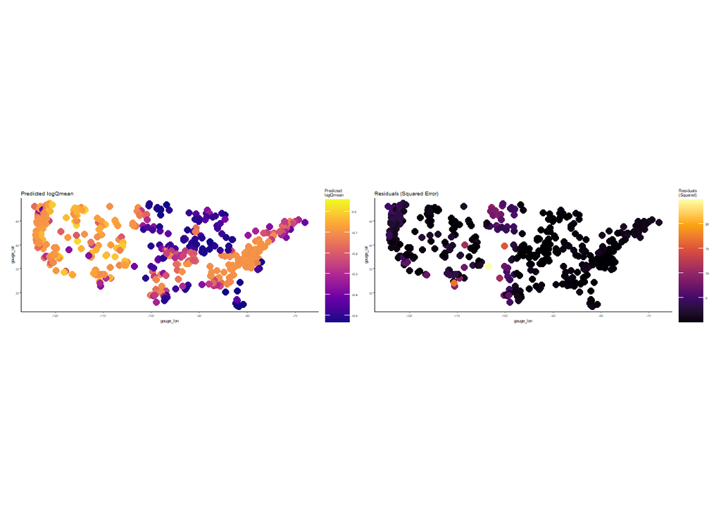

```r
# Map of Predictions
map_pred <- ggplot(aug_data, aes(x = gauge_lon, y = gauge_lat, color = .pred)) +
  geom_point(size = 2) +
  coord_fixed() +
  scale_color_viridis_c(option = "plasma", name = "Predicted\nlogQmean") +
  labs(title = "Predicted logQmean") +
  theme_classic(base_size = 3)

# Map of Residuals
map_resid <- ggplot(aug_data, aes(x = gauge_lon, y = gauge_lat, color = residuals)) +
  geom_point(size = 2) +
  coord_fixed() +
  scale_color_viridis_c(option = "inferno", name = "Residuals\n(Squared)") +
  labs(title = "Residuals (Squared Error)") +
  theme_classic(base_size = 3)

# Combine the two maps using patchwork
final_plot <- map_pred | map_resid +
  plot_annotation(title = "Predictions and Residuals Across Sites")

# Display
final_plot
```